# Amniotic fluid RNA gene expression profiling provides insights into the phenotype of Turner syndrome

Helena Martin Hernández

19/5/2020

GitHub Repository Link: https://github.com/hemahecodes/Omics-Techniques-2020.git

### Description of the study

Turner syndrome is a chromosomal condition that affects the development on females. Some common features of Turner syndrome are:

- Short stature
- Loss of ovarian function
- Webbed neck
- Lymphedema
- Coarctation of the aorta

On this study, the fetal amniotic fluid is a complex biological material used to understand the Turner syndrome pathogenesis. Cell-free RNA from amniotic fluid of five mid-trimester Turner syndrome fetuses and five euploid female fetuses was extracted, amplified, and hybridized onto affymetrix arrays. Then, significantly differentially regulated genes were identified. [^1]

### Main objective of the study

The study aims to understand which genes and organ systems play a role in Turner syndrome pathophysiology by analyzing extracellular RNA in amniotic fluid. The data consists of several genes with their expression frequency on the different fetus.

**Response variable**: Expression of genes **Groups**: 2 ***Sample size**: 10, 5 fetuses with Turner syndrome and 5 fetuses without Turner syndrome.

First, we have to download the data. We can do it using the getGEO function.

```r
library(GEOquery)
library(limma)
library(Biobase)
gset <- getGEO("GSE58435", GSEMatrix =TRUE, AnnotGPL=TRUE)
```

```
## Found 1 file(s)
```

```
## GSE58435_series_matrix.txt.gz
```

```
## File stored at:
```

```
## C:\Users\Public\Documents\Wondershare\CreatorTemp\RtmpYPboFX/GPL570.annot.gz
```

```r
data <- exprs(gset[[1]])
```

Now, we can take a first look to the data. With the following command we can extract a summary of our data.

```r
gset[[1]]
```

```
## ExpressionSet (storageMode: lockedEnvironment)
## assayData: 54675 features, 10 samples
##   element names: exprs
## protocolData: none
## phenoData
##   sampleNames: GSM1411021 GSM1411022 ... GSM1411030 (10 total)
##   varLabels: title geo_accession ... karyotype:ch1 (34 total)
##   varMetadata: labelDescription
## featureData
##   featureNames: 1007_s_at 1053_at ... AFFX-TrpnX-M_at (54675 total)
##   fvarLabels: ID Gene title ... GO:Component ID (21 total)
##   fvarMetadata: Column Description labelDescription
## experimentData: use 'experimentData(object)'
##   pubMedIds: 24850140
## Annotation: GPL570
```

To obtain numerical summaries as the number of rows and columns in our data we can use the following command:

```r
dim(exprs(gset[[1]]))
```

```
## [1] 54675    10
```

We observe that the have 10 columns, each of these columns represents one sample of the study, ans 54675 rows, which represent the different genes analyzed.

Now, lets observe the data by doing some plots. To understand better how the data is represented we can perform a plot for a single gene.

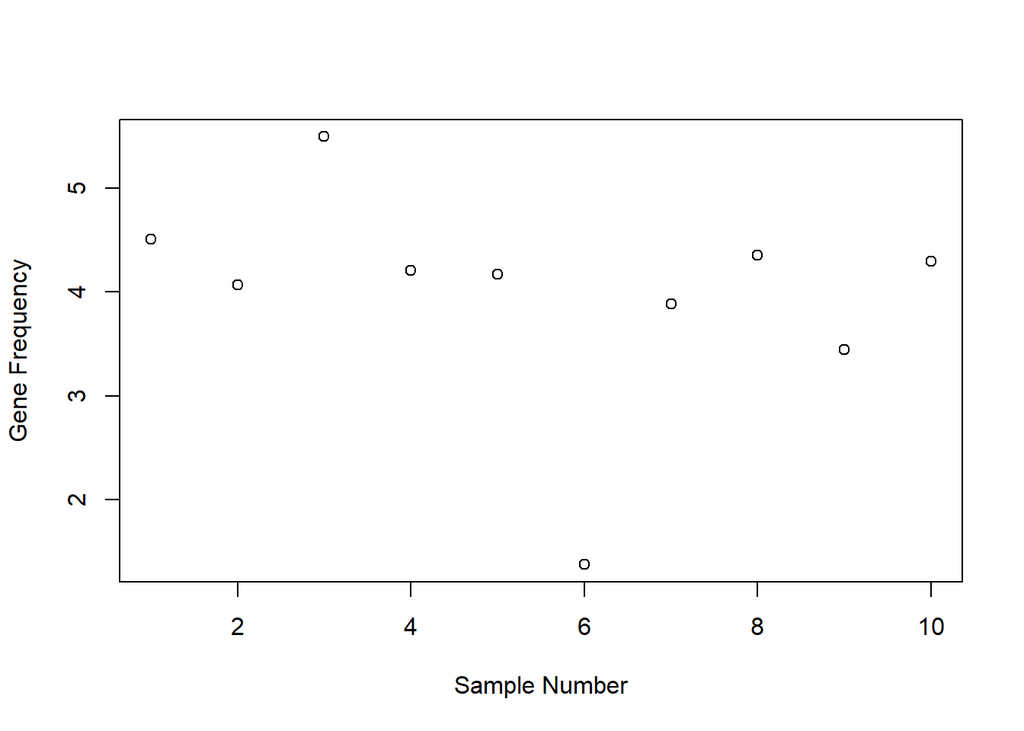

```r
plot(data[1,], ylab= 'Gene Frequency', xlab='Sample Number')
```

On this plot we can observe that for each gene, each sample has a value corresponding to the frequency of this gene. Note that 5 samples correspond to fetuses with Turner syndorme, and the other 5 samples correspond to fetuses without Turner syndorm. Therefore, in this study we have 2 groups. Performing an analysis of all the genes and comparing the results between the two groups can help us to obtain more information about the Turner syndrome and what genes are involved on the phenotypic alterations.

### Design Matrix

```r
design_matrix<- matrix(c(1,1,1,1,1,2,2,2,2,2,1,1,1,1,1,0,0,0,0,0,0,0,0,0,0,1,1,1,1,1), nrow = 10,ncol = 3, dimnames =list(c("Sample 1","Sample 2","Sample 3","Sample 4","Sample 5","Sample 6","Sample 7","Sample 8","Sample 9","Sample 10"), c("Group", "| Turner Group","| Control Group")))

design_matrix
```

```
##           Group | Turner Group | Control Group
## Sample 1      1              1               0
## Sample 2      1              1               0
## Sample 3      1              1               0
## Sample 4      1              1               0
## Sample 5      1              1               0
## Sample 6      2              0               1
## Sample 7      2              0               1
## Sample 8      2              0               1
## Sample 9      2              0               1
## Sample 10     2              0               1
```

### Contrast Matrix

```r
if (length(gset) > 1) idx <- grep("GPL570", attr(gset, "names")) else idx <- 1
gset <- gset[[idx]]

# Define the column names properly:
fvarLabels(gset) <- make.names(fvarLabels(gset))

gsms <- "1111100000"
sml <- c()
for (i in 1:nchar(gsms)) { sml[i] <- substr(gsms,i,i) }


# log2 transform:
ex <- exprs(gset)
qx <- as.numeric(quantile(ex, c(0., 0.25, 0.5, 0.75, 0.99, 1.0), na.rm=T))
LogC <- (qx[5] > 100) ||
  (qx[6]-qx[1] > 50 && qx[2] > 0) ||
  (qx[2] > 0 && qx[2] < 1 && qx[4] > 1 && qx[4] < 2)
if (LogC) { ex[which(ex <= 0)] <- NaN
exprs(gset) <- log2(ex) }

#Set group names:
sml <- paste("G", sml, sep="")

#Contrast matrix:
fl <- as.factor(sml)
gset$description <- fl
design <- model.matrix(~ description + 0, gset)
colnames(design) <- levels(fl)
fit <- lmFit(gset, design)

cont.matrix <- makeContrasts(G1-G0, levels=design)
cont.matrix
```

```
##       Contrasts
## Levels G1 - G0
##     G0      -1
##     G1       1
```

### Fit Model

```r
model_fit <- contrasts.fit(fit, cont.matrix)
model_fit <- eBayes(model_fit, 0.01)
```

### Volcano Plot

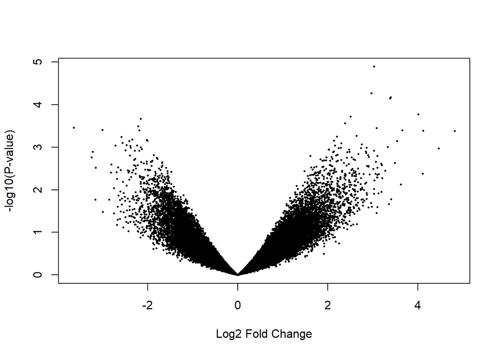

```r
volcanoplot(model_fit)
```

### Top Table

```r
top_Table <- topTable(model_fit, adjust="fdr", sort.by="B", number=250)
top_Table <- subset(top_Table, select=c("ID","adj.P.Val","P.Value","t","B","logFC","Gene.symbol","Gene.title"))
top_Table
```

```
##                        ID adj.P.Val      P.Value         t         B     logFC
## 201282_at       201282_at 0.7007491 1.281663e-05  6.773810 -4.468046  3.031999
## 217232_x_at   217232_x_at 0.9788708 5.409429e-05  5.868340 -4.477733  2.969720
## 210719_s_at   210719_s_at 0.9788708 6.672291e-05  5.742075 -4.479320  3.396428
## 235361_at       235361_at 0.9788708 7.161377e-05  5.699805 -4.479866  3.382755
## 207092_at       207092_at 0.9997918 1.693045e-04  5.197041 -4.486967  4.011486
## 228499_at       228499_at 0.9997918 1.903590e-04  5.130082 -4.488003  2.510947
## 235719_at       235719_at 0.9997918 2.133572e-04 -5.065256 -4.489028 -2.156150
## 230445_at       230445_at 0.9997918 2.736306e-04  4.924930 -4.491321  2.381681
## 1569386_at     1569386_at 0.9997918 3.180007e-04 -4.840876 -4.492746 -2.210268
## 215388_s_at   215388_s_at 0.9997918 3.454539e-04 -4.794777 -4.493543 -3.641796
## 204957_at       204957_at 0.9997918 3.517830e-04  4.784690 -4.493719  3.084771
## 201656_at       201656_at 0.9997918 3.927838e-04 -4.723592 -4.494798 -3.004514
## 219812_at       219812_at 0.9997918 3.989222e-04 -4.715019 -4.494951 -2.187575
## 1557905_s_at 1557905_s_at 0.9997918 4.036005e-04  4.708577 -4.495067  3.655535
## 239792_at       239792_at 0.9997918 4.093635e-04  4.700746 -4.495207  4.118287
## 204875_s_at   204875_s_at 0.9997918 4.135634e-04  4.695111 -4.495308  4.821249
## 226235_at       226235_at 0.9997918 5.360729e-04  4.552598 -4.497932  2.636426
## 229069_at       229069_at 0.9997918 5.593731e-04  4.529357 -4.498371  2.199006
## 227795_at       227795_at 0.9997918 5.775607e-04 -4.511902 -4.498703 -2.582135
## 215163_at       215163_at 0.9997918 6.622856e-04 -4.437447 -4.500140 -2.346360
## 230322_at       230322_at 0.9997918 6.794191e-04 -4.423593 -4.500411 -2.025207
## 1563943_at     1563943_at 0.9997918 7.045181e-04 -4.403937 -4.500798 -2.004392
## 1558608_a_at 1558608_a_at 0.9997918 7.076779e-04  4.401513 -4.500846  2.139935
## 1557316_at     1557316_at 0.9997918 7.083553e-04 -4.400995 -4.500856 -2.410218
## 223054_at       223054_at 0.9997918 7.113049e-04  4.398746 -4.500901  3.539849
## 216191_s_at   216191_s_at 0.9997918 7.961308e-04 -4.337868 -4.502115 -2.554985
## 1557315_a_at 1557315_a_at 0.9997918 8.061963e-04  4.331093 -4.502252  2.301104
## 221432_s_at   221432_s_at 0.9997918 8.512737e-04  4.301785 -4.502846  2.759967
## 236427_at       236427_at 0.9997918 8.864184e-04 -4.280025 -4.503291 -2.464506
## 1553396_a_at 1553396_a_at 0.9997918 9.033390e-04 -4.269863 -4.503500 -2.234970
## 206483_at       206483_at 0.9997918 9.138681e-04  4.263639 -4.503628  2.160915
## 205614_x_at   205614_x_at 0.9997918 9.182098e-04 -4.261094 -4.503680 -2.718114
## 203469_s_at   203469_s_at 0.9997918 9.329305e-04 -4.252556 -4.503857 -2.381097
## 221770_at       221770_at 0.9997918 9.793886e-04  4.226492 -4.504398  3.334466
## 231361_at       231361_at 0.9997918 9.982284e-04 -4.216284 -4.504611 -2.149207
## 214336_s_at   214336_s_at 0.9997918 1.022248e-03  4.203553 -4.504878  2.865236
## 211741_x_at   211741_x_at 0.9997918 1.030243e-03 -4.199384 -4.504965 -2.377817
## 241962_at       241962_at 0.9997918 1.035341e-03  4.196743 -4.505021  2.292072
## 207594_s_at   207594_s_at 0.9997918 1.045289e-03  4.191628 -4.505128  2.244290
```

[output cut: 698 more lines]

[output not shown]

[^1]: Amniotic Fluid RNA Gene Expression Profiling Provides Insights Into the Phenotype of Turner Syndrome: Lauren J Massingham 1, Kirby L Johnson, Thomas M Scholl, Donna K Slonim, Heather C Wick, Diana W Bianchi